Econometrics and Statistics (520K)

# Econometric Methods in Business and Economics

Practical Class (Winter 24/25)

by Domenic Franjic

# Exercise Sheet No 03

Linear Regression with One Regressor (Part 2)

We continue our analysis of the relationship between student performance and class size.

For this we use again the data set `CASchool_01_data.txt` and the two variables $test score$ and $STR$ as obtained in the first exercise sheet.

Variables

| Variable | Description |
| --- | --- |
| $students$ | Total enrollment. |
| $teachers$ | Number of teachers. |
| $read$ | Average reading score. |
| $math$ | Average math score. |

## Set-Up

1) Create your (working) directory

Create a new folder on your computer in which you can save all necessary files, i.e., the data set, the R *script* with the implementation of your analysis and the R *helper function script* with some helper functions provided by us.

This folder, i.e., the path or directory of this folder, will be your so-called working directory.

2) Download the data set

Download the data sets `CASchools_01_data.txt` from ILIAS or by using the link below:

[Download `CASchools_01_data.txt`](https://ilias.uni-hohenheim.de/goto.php?target=file_1523858_download&client_id=UHOH)

Save the data set into your (working) directory.

3) Prepare *script*

Open a new R *script* and save it into into your (working) directory.

Run the following code chunk to prepare your R *script*, i.e., to clear the work space and set your working directory.

```r
# Clear workspace
rm(list = ls(all = TRUE))
# Set working directory
setwd(".../set/your/working/directory/...")
```

4) Install/load *packages* and download/save/include *helper function script*

Step 1) Install all relevant R *packages* and download and save the R *script* `r_helper_functions.R` from ILIAS by running the following code chunk.

```r
# Download R-helper functions
source("https://ilias.uni-hohenheim.de/data/UHOH/lm_data/lm_1856939/MA_EconometricMethods_WiSe2324_PracticalClass/r-scripts/prepare_r_packages_and_helper_functions.R")
```

*Note*, the required R *packages* are `"moments"`, `"sandwich"`, `"lmtest"`, `"lmtest"`, `"car"`, `"plm"`, `"ivreg"`, `"dynlm"`, `"forecast"`, `"urca"`.

Step 2) Include the R *script* `r_helper_functions.R` into your R *script* by running the following code chunk.

```r
# Include R-helper functions
source("r_helper_functions.R")
```

*Note*, more information on the helper functions can be found here.

## Preparations

Load data, construct variables and estimation results.

Load data set

```r
# use absolute or relative path to load data
cas.dat <- read.table(file = "CASchools_01_data.txt",
                      header = TRUE,
                      sep = ",",
                      colClasses = c("numeric","numeric","numeric","numeric"))
```

Construct variables

```r
# compute STR and append it to cas.dat
cas.dat$STR <- cas.dat$students/cas.dat$teachers
# compute TestScore and append it to cas.dat
cas.dat$score <- (cas.dat$read + cas.dat$math)/2
```

Estimation results

```r
# estimate the model and assign the result to lin.mod
lin.mod <- lm(score ~ STR, data = cas.dat)
# show results
lin.mod
```

```
##
## ========================
##            Model 1
## ------------------------
## intercept  698.93 (9.47)
## STR         -2.28 (0.48)
## ------------------------
## R^2          0.05
## RMSE        18.58
## ========================
```

Summary of estimation results

```r
# summary of estimation results
sum.lin.mod <- summary(lin.mod)
```

The object `sum.lin.mod` is of class `summary.lm` and contains various summary information about the model fitting.

E.g., you can extract the standard error of the regression (SER), $R^2$, and adjusted $R^2$.

These information can be extracted using the `$` notation.

```r
# standard error of the regression
sum.lin.mod$sigma
```

```
## [1] 18.58097
```

```r
# R^2
sum.lin.mod$r.squared
```

```
## [1] 0.05124009
```

```r
# adjusted R^2
sum.lin.mod$adj.r.squared
```

```
## [1] 0.04897033
```

## Task a)

Related to the `father’s question’ from the lecture predict the variable $test score$ for a district with 16 students per teacher and for a district with 21 students per teacher. Calculate the out-of-sample and the in-sample prediction error if possible.

$\underline{STR=16}$

```r
# potential index of STR=16
ii.16 <- which(cas.dat$STR == 16)
ii.16 # -> out-of-sample prediction
# predicted score for STR=16
pre.16 <- 698.93 - 2.28*16
pre.16
```

```
## integer(0)
```

```
## [1] "predicted score (STR=16): 662.45"
```

$\underline{STR=21}$

```r
# potential index of STR=21
ii.21 <- which(cas.dat$STR == 21)
ii.21 # -> in-sample prediction
# predicted score for STR=21
pre.21 <- 698.93 - 2.28*21
pre.21
```

```
## [1] 12
```

```
## [1] "predicted score (STR=21): 651.05"
```

Use the function `which()` to check whether the prediction for $STR=16$ and $STR=21$ is an out-of-sample and the in-sample prediction.

In-sample prediction error for $\underline{STR=21}$

```r
# score for STR=21
sco.21 <- cas.dat$score[ii.21]
# in-sample prediction error STR=21
res.21 <- sco.21-pre.21
res.21
```

```
## [1] "in-sample prediction error STR=21: -34.75"
```

Prediction Error (general)

$$\begin{align*}
\widehat{u}_{i} = Y_{i} - \widehat{Y}_{i}
\end{align*}$$

Particular:

- Prediction of $score$ for $STR=16$:
  - Out-of-sample prediction $\Rightarrow$ $Y$ is not observable
  - See: $SER$ for the evaluation of the prediction later
- Prediction of $score$ for $STR=21$ (In-sample prediction):

$$\begin{align*}
\widehat{u}_{i} &= Y_{i} - \widehat{Y}_{i} \\
&= -34.75
\end{align*}$$

*Add your interpretation here!*

## Task b)

Based on the information about the fit of the regression line depicted in Table 1 of the exercise sheet evaluate the prediction of task a) and state the least squares assumptions for prediction.

```r
# standard error of the regression
ser <- sum.lin.mod$sigma
# prediction and its accuracy for STR=16
pre.16 + ser
pre.16
pre.16 - ser
# prediction and its accuracy for STR=21
pre.21 + ser
pre.21
pre.21 - ser
```

```
## [1] "STR=16 (upp): 681.03"
```

```
## [1] "STR=16 (mid): 662.45"
```

```
## [1] "STR=16 (low): 643.87"
```

```
## [1] "STR=21 (upp): 669.63"
```

```
## [1] "STR=21 (mid): 651.05"
```

```
## [1] "STR=21 (low): 632.47"
```

Prediction Accuracy (proposal)

- Use standard deviation of the out-of-sample / in-sample prediction error (unknown).
- Estimate the standard deviation of the in-sample prediction error, i.e., standard error of the regression $SER$.

Results Application

$\underline{STR=16}$:

$$\begin{align*}
&\phantom{:} \left[662.45 - 18.58, 662.45 + 18.58\right] \\
&\phantom{:} \left[643.87, 681.03\right]
\end{align*}$$

$\underline{STR=21}$:

$$\begin{align*}
&\phantom{:} \left[651.05 - 18.58, 651.05 + 18.58\right] \\
&\phantom{:} \left[632.47, 669.63\right]
\end{align*}$$

Least-Squares Assumptions for Prediction

1. Out-of-sample observation $\left(X^{OOS},Y^{OOS}\right)$ is drawn from the same distribution as the estimation sample, i.e. in-sample observations $\left(X_{i},Y_{i}\right)$ for $i=1,...,n$.
2. $\left(X_{i},Y_{i}\right)$ for $i=1,...,n$ are i.i.d.
3. Large outliers in $X$ and/or $Y$ are rare.

*Add your interpretation here!*

## Task c)

Replicate the results in Table 1 of the exercise sheet and discuss the role of the robust standard errors depicted the table.

Estimate linear regression model (same as task a))

```r
# estimate the model and assign the result to lin.mod
lin.mod <- lm(score ~ STR, data = cas.dat)
# show results
summary(lin.mod)
```

```
##
## Call:
## lm(formula = score ~ STR, data = cas.dat)
##
## Residuals:
##     Min      1Q  Median      3Q     Max
## -47.727 -14.251   0.483  12.822  48.540
##
## Coefficients:
##             Estimate Std. Error t value Pr(>|t|)
## (Intercept) 698.9329     9.4675  73.825  < 2e-16 ***
## STR          -2.2798     0.4798  -4.751 2.78e-06 ***
## ---
## Signif. codes:  0 '***' 0.001 '**' 0.01 '*' 0.05 '.' 0.1 ' ' 1
##
## Residual standard error: 18.58 on 418 degrees of freedom
## Multiple R-squared:  0.05124,    Adjusted R-squared:  0.04897
## F-statistic: 22.58 on 1 and 418 DF,  p-value: 2.783e-06
```

Scatter Plot with Fitted Regression Line

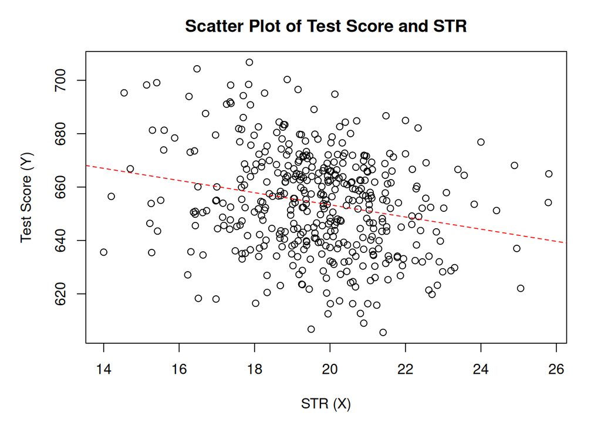

```r
# plot parameters
par(mfrow = c(1,1),
    mar = c(5,5,3,2))
# scatter plot
plot(cas.dat$STR, cas.dat$score,
     main = "Scatter Plot of Test Score and STR",
     xlab = "STR (X)",
     ylab = "Test Score (Y)")
abline(lin.mod, col = "red", lty = 2)
```

Extract variance-covariance matrix of estimates

Standard error based on homoskedasticity only

```r
# install package once
#install.packages("sandwich")
# load package every session
library(sandwich)
# extract standard errors based on homoskedasticity
vc.ord.01 <- vcovHC(lin.mod, type = "const")
se.ord.01 <- sqrt(diag(vc.ord.01))
se.ord.01
```

```
## (Intercept)         STR
##   9.4674911   0.4798255
```

Standard error robust w.r.t. heteroskedasticity

```r
# load package every session
library(sandwich)
# extract heteroskedasticity-robust standard erros (based on White)
vc.rob.01 <- vcovHC(lin.mod, type = "HC1")
se.rob.01 <- sqrt(diag(vc.rob.01))
se.rob.01
```

```
## (Intercept)         STR
##  10.3643617   0.5194893
```

- Download (once) and load (every session) the *package* `sandwich` to use the *function* `vcovHC()` to extract robust standard errors for the estimated coefficients.
- Use the *function* `vcovHC` to extract the variance-covariance matrix of the estimated coefficients, here, $\beta_0$ and $\beta_1$, based on the assumption of homoskedasticity only (`type="const"`) and robust w.r.t to heteroskedasticity (`type="HC1"`).
- Use the *functions* `sqrt()` and `diag()` to get the standard errors based on homoskedasticity only (`se.ord.01`) and robust w.r.t. heteroskedasticity (`se.rob.01`).

Standard error robust w.r.t. heteroskedasticity: Use *wrapper function* `lm_ct_fun()` from above

```r
# call wrapper function for robust inference
lin.mod.rob <- lm_ct_fun(score ~ STR, data = cas.dat, hc.type = "HC1")
# print results
lin.mod.rob$ct
```

```
##
## t test of coefficients:
##
##              Estimate Std. Error t value  Pr(>|t|)
## (Intercept) 698.93295   10.36436 67.4362 < 2.2e-16 ***
## STR          -2.27981    0.51949 -4.3886 1.447e-05 ***
## ---
## Signif. codes:  0 '***' 0.001 '**' 0.01 '*' 0.05 '.' 0.1 ' ' 1
```

Sampling distribution of $\widehat{\beta}_1$

$$\begin{align}
\widehat{\beta}_1 \sim N\left(\beta_1, \sigma^2_{\widehat{\beta}_1}
\right) \;\;\; \text{(approximately)}
\end{align}$$

with (heteroskedasticity robust)

$$\begin{align}
\sigma^2_{\widehat{\beta}_1}=\frac{1}{n}\frac{\mathrm{var}\left[\left(X_i-\mu_X\right)u_i\right]}{\left[\mathrm{var}\left(X_i\right)\right]^2}
\end{align}$$

under homoskedasticity

$$\begin{align}
\tilde{\sigma}^2_{\widehat{\beta}_1}=\frac{1}{n}\frac{\mathrm{var}\left[u_i\right]}{\left[\mathrm{var}\left(X_i\right)\right]^2}
\end{align}$$

Important

- Using heteroskedasticity robust SE is more complicated but more robust.
- Heteroskedasticity robust SE are readily available in almost any statistics software.
- $\Rightarrow$ In case of doubt use heteroskedasticity robust standard error!

*Add your interpretation here!*

Back To *Start* of *Practical Class*